Lauren Green, March 2018

# Analyzing the Stroop Effect

Perform the analysis in the space below. Remember to follow [the instructions](https://docs.google.com/document/d/1-OkpZLjG_kX9J6LIQ5IltsqMzVWjh36QpnP2RYpVdPU/pub?embedded=True) and review the [project rubric](https://review.udacity.com/#!/rubrics/71/view) before submitting. Once you've completed the analysis and write up, download this file as a PDF or HTML file and submit in the next section.

- Introduction
- Method
- Results
- Conclusion
- References

## Introduction

In this experiment, the Stroop effect was investigated for a sample group of people who took part in an experiment. In a Stroop experiment, participants are given a list of words in an ink colour and the participant's task is to say the colour of the ink the word is printed in out loud, regardless of what the printed word says.

There are two conditions: a congruent words condition and an incongruent words condition. For the congruent case, the ink colour of the words displayed match the meaning of the word printed, for example RED, BLUE. For the incongruent words condition, the ink colour of the words do not match the word meaning, for example PURPLE, ORANGE. In each case, the time taken to name the ink colours using equally sized lists is recorded.

**What is the independent variable? What is the dependent variable?**

An *independent* variable is the variable that is changed or controlled in an experiment. In this case, the independent variable is the test condition, whether the words condition are congruent or incongruent.

The *dependent* variable is the variable that is tested in an experiment; a change in the independent variable causes a change in the dependent variable. The dependent variable for this experiment is the time taken to complete the experiment, in other words the time taken to complete naming the ink colours of the words.

```python
# Import Libraries
import numpy as np
import pandas as pd
import scipy.stats as stats
import matplotlib.pyplot as plt

# Enable inline viewing of graphs
%matplotlib inline
```

## Method

**What is an appropriate set of hypotheses for this task? What kind of statistical test do you expect to perform? Justify your choices.**

### Hypotheses

Our **null hypothesis** will be that there is no difference in the recorded reading times for the congruent and incongruent word conditions. In other words, the population mean reading time for the incongruent condition is equal to the population mean reading time for the congruent condition.

The **alternative hypothesis** is that there is a difference in the time taken to read text that is displayed as incongruent than the reading time for text that is displayed as congruent. The population mean reading time for the incongruent and congruent conditions are different.

The null and alternative hypotheses are as follows, in notation:

$$\mu_{diff} = \mu_{I} - \mu_{C}$$

$$H_0: \mu_{diff} = 0$$

$$H_1: \mu_{diff} \neq 0$$

where,

$\mu_{I}$ and $\mu_{C}$ are the population mean reading times for the incongruent and congruent word conditions, respectively. $\mu_{diff}$ is the population mean difference between the two word conditions.

If $\mu_{diff}$ is much greater than zero (a large positive number), then we can say that the reading time is longer for the incongruent word condition than the reading time for the congruent word condition.

If $\mu_{diff}$ is significantly less than zero, we can conclude that the reading times for the incongruent word condition is shorter than the reading time for the congruent word condition.

```python
# Read in csv
df = pd.read_csv('stroopdata.csv')

# Print dataframe and check sample size
df
```

|  | Congruent | Incongruent |
| --- | --- | --- |
| 0 | 12.079 | 19.278 |
| 1 | 16.791 | 18.741 |
| 2 | 9.564 | 21.214 |
| 3 | 8.630 | 15.687 |
| 4 | 14.669 | 22.803 |
| 5 | 12.238 | 20.878 |
| 6 | 14.692 | 24.572 |
| 7 | 8.987 | 17.394 |
| 8 | 9.401 | 20.762 |
| 9 | 14.480 | 26.282 |
| 10 | 22.328 | 24.524 |
| 11 | 15.298 | 18.644 |
| 12 | 15.073 | 17.510 |
| 13 | 16.929 | 20.330 |
| 14 | 18.200 | 35.255 |
| 15 | 12.130 | 22.158 |
| 16 | 18.495 | 25.139 |
| 17 | 10.639 | 20.429 |
| 18 | 11.344 | 17.425 |
| 19 | 12.369 | 34.288 |
| 20 | 12.944 | 23.894 |
| 21 | 14.233 | 17.960 |
| 22 | 19.710 | 22.058 |
| 23 | 16.004 | 21.157 |

```python
# Make a series for the difference in Incongruent and Congruent data
series_diff = df['Incongruent'] - df['Congruent']

# Convert difference series to DataFrame
df_diff = pd.DataFrame({"Difference":series_diff})

df_diff
```

|  | Difference |
| --- | --- |
| 0 | 7.199 |
| 1 | 1.950 |
| 2 | 11.650 |
| 3 | 7.057 |
| 4 | 8.134 |
| 5 | 8.640 |
| 6 | 9.880 |
| 7 | 8.407 |
| 8 | 11.361 |
| 9 | 11.802 |
| 10 | 2.196 |
| 11 | 3.346 |
| 12 | 2.437 |
| 13 | 3.401 |
| 14 | 17.055 |
| 15 | 10.028 |
| 16 | 6.644 |
| 17 | 9.790 |
| 18 | 6.081 |
| 19 | 21.919 |
| 20 | 10.950 |
| 21 | 3.727 |
| 22 | 2.348 |
| 23 | 5.153 |

### Statistical t-test

We are given a sample size of n = 24. Below is a [figure](http://www.statisticshowto.com/probability-and-statistics/hypothesis-testing/t-score-vs-z-score/) that depicts when to use a t-test versus a z-score.

[figure not shown]

We therefor use a t-test to analyze the two sample means (congruent and incongruent) as we have a small sample size that is less than 30 and the population standard deviation is unkown for our sample.

A t-test is used to tell if there is a significant difference before and after results or if the difference could have been by chance. Usually t-tests are used to test if means are different. A larger t-value suggests a larger difference in the two samples.

A two-tailed paired/ dependent t-test for means will be conducted. This type of t-test is usually used when your data has two observations from the same group. Here we have the same group of people recording the mean time to say the words out loud for two test conditions (congruent and incongruent word cases) for a sample size of n = 24. Thus we assume that our sample is dependent and therefor it is possible to pair them. We would like to test if there is any difference in the mean reading/ reaction times for the congruent and incongruent cases.

## Results

### Descriptive Statistics

**Report some descriptive statistics regarding this dataset. Include at least one measure of central tendency and at least one measure of variability. The name of the data file is 'stroopdata.csv'.**

```python
# Descriptive statistics about df
df.describe()
```

|  | Congruent | Incongruent |
| --- | --- | --- |
| count | 24.000000 | 24.000000 |
| mean | 14.051125 | 22.015917 |
| std | 3.559358 | 4.797057 |
| min | 8.630000 | 15.687000 |
| 25% | 11.895250 | 18.716750 |
| 50% | 14.356500 | 21.017500 |
| 75% | 16.200750 | 24.051500 |
| max | 22.328000 | 35.255000 |

```python
# Descriptive statistics for the difference
df_diff.describe()
```

|  | Difference |
| --- | --- |
| count | 24.000000 |
| mean | 7.964792 |
| std | 4.864827 |
| min | 1.950000 |
| 25% | 3.645500 |
| 50% | 7.666500 |
| 75% | 10.258500 |
| max | 21.919000 |

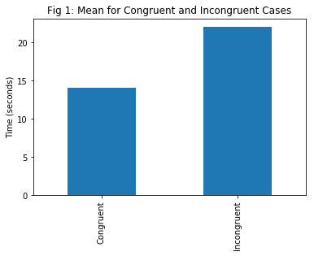

```python
df.mean().plot('bar')
plt.title('Fig 1: Mean for Congruent and Incongruent Cases')
plt.ylabel('Time (seconds)');
```

The mean is an example of central tendancy. Here the mean for the congruent case is 14 and the mean for the incongruent case is 22, this can be visually seen in *Fig 1*. The mean for the congruent case is much smaller than the mean for the incongruent case, the difference is approximately 8.

The standard deviation is a measure of variablity. The standard deviation for the congruent case is 3.6 and 4.8 for the incongruent case.

### Visualisations

**Provide one or two visualizations that show the distribution of the sample data. Write one or two sentences noting what you observe about the plot or plots.**

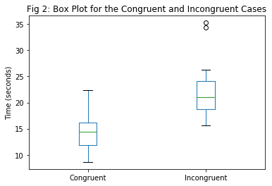

```python
# Box plot for congruent and incongruent data
df.plot.box()
plt.title('Fig 2: Box Plot for the Congruent and Incongruent Cases')
plt.ylabel('Time (seconds)');
```

```python
# Computing IQR for the Congruent Data
Q1 = df['Congruent'].quantile(0.25)
Q3 = df['Congruent'].quantile(0.75)
IQR_C = Q3 - Q1

IQR_C
```

```
4.3054999999999986
```

```python
# Computing IQR for the Incongruent Data
Q1 = df['Incongruent'].quantile(0.25)
Q3 = df['Incongruent'].quantile(0.75)
IQR_I = Q3 - Q1

IQR_I
```

```
5.33475
```

```python
# Computing the range for the Congruent and Incongruent Data
range_df = df.max() - df.min()

range_df
```

```
Congruent      13.698
Incongruent    19.568
dtype: float64
```

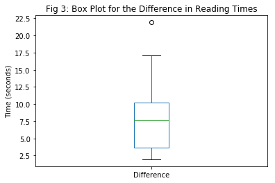

```python
# Box plot for congruent and incongruent data
df_diff.plot.box()
plt.title('Fig 3: Box Plot for the Difference in Reading Times')
plt.ylabel('Time (seconds)');
```

*Fig 2* depicts the boxplot for the congruent and incongruent cases. Here we can visually see the difference in the medians for both cases: the median for the incongruent data (21) is larger than the median for the congruent data (14).

There are two outliers for the incongruent data at around time = 35 seconds, however, there are no outliers for the congruent data. The box plot for the congruent data is slightly negatively skewed, whereas the incongruent data is slightly positively skewed.

The Inter-Quartile Range (IQR) is smaller for the congruent data (4.3) than for the incongruent data (5.3). The range for the incongruent data is larger (19.6) than the range for the congruent data (13.7).

*Fig 3* depicts the difference of the incongruent data minus the congruent data. There is one outlier around 22. The median difference between the two cases is 7.7.

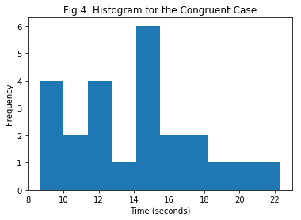

```python
# Histogram for Congruent data
df['Congruent'].plot.hist(stacked=False, bins = 10)
plt.title('Fig 4: Histogram for the Congruent Case')
plt.ylabel('Frequency')
plt.xlabel('Time (seconds)');
```

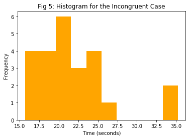

```python
# Histogram for Incongruent data
df['Incongruent'].plot.hist(stacked=False, bins = 10, color='orange')
plt.title('Fig 5: Histogram for the Incongruent Case')
plt.ylabel('Frequency')
plt.xlabel('Time (seconds)');
```

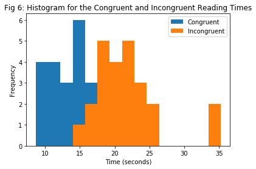

```python
# Histogram for congruent and incongruent data
df.plot.hist(stacked=False, bins = 15)
plt.title('Fig 6: Histogram for the Congruent and Incongruent Reading Times')
plt.ylabel('Frequency')
plt.xlabel('Time (seconds)');
```

*Fig 4* and *Fig 5* depicts the histogram for the congruent and incongruent cases respectivley. The shape if the distributions is unclear, more data is needed to form a better distribution of data. It is clear that the incongruent case has some outliers as seen in *Fig 5*, outliers were not removed in this study.

Both the histograms for the congruent and incongruent cases are plotted in *Fig 6*. Here we can see that the congruent case had a faster reading time than the incongruent case.

### Dependent T-Test

**Now, perform the statistical test and report the results. What is the confidence level and your critical statistic value? Do you reject the null hypothesis or fail to reject it? Come to a conclusion in terms of the experiment task. Did the results match up with your expectations?**

We use a dependent or paired t-test as our sample is the same group of people conducting the experiment with two differenct test conditions (congruent and incongruent). A 95% confidence interval was assumed, $\alpha = 0.05$ (a 5% statistical significance level).

```python
# We need a list/array instead of a column in a dataframe for a t-test
congruent_list = df['Congruent'].tolist()
incongruent_list = df['Incongruent'].tolist()

# T-test for two dependent samples
t_test = stats.ttest_rel(incongruent_list, congruent_list)

print('t-statistic = {}'.format(t_test[0]))
print('p-value = {}'.format(t_test[1]))
```

```
t-statistic = 8.020706944109957
p-value = 4.103000585711178e-08
```

From the dependent t-test, we found that the t-statistic was 8.02 and the p-value was 0.00000004.

We reject the null hypothesis (that there is no difference in the recorded reading times for the congruent and incongruent word conditions) since the p-value is much less than 0.05 (using a 95% confidence interval). Thus, we accpect the alternative hypothesis that that there is a difference in the time taken to read text that is displayed as incongruent than the reading time for text that is displayed as congruent. This result matches what was expected before the statistical test was conducted that the incogruent case would have longer reading times than the congruent case.

We could also use the t-statistic to get the same result as using the p-value. We find the t-critical value using t-tables or [Graphpad](https://www.graphpad.com/quickcalcs/statRatio2/), using 23 degrees of freedom and $\alpha = 0.05$ (95% confidence interval). The t-critical value was found to be greater than 2.069 or less than -2.0687. Since our t-statistic of 8.02 is past this critical value, again, we reject the null.

## Conclusion

In conclusion, using a two-tailed dependent samples t-test, it was found that there is that there is a statistical difference in the time taken to read text that is displayed as incongruent than the reading time for text that is displayed as congruent.

Furthermore, it was found that on average, the reading times for the incongruent word conditions had longer reading times than that of the congruent word conditions. A potential explanation for this that when we have to recognise the colour of the word but the word description is different to the colour, there is an interference in the reaction time, causing a longer reading time. This interferance can be explained by the following [theories](https://faculty.washington.edu/chudler/words.html):

- Speed of Processing Theory: interference can be explained because words are read faster than colors can be named,
- Selective Attention Theory: interference occurs as naming colors requires more attention than reading words.

A similar experiment is the ["Number Stroop" effect experiment](https://faculty.washington.edu/chudler/java/readyn.html). Here one is required to count the number of words in a box and give the numerical amount, not name what the word says. The image below depicts an example of this experiment:

[figure not shown]

## References

- https://stackoverflow.com/questions/19746350/how-does-one-change-color-in-markdown-cells-ipython-jupyter-notebook
- http://www.statisticshowto.com/probability-and-statistics/hypothesis-testing/t-score-vs-z-score/
- https://pandas.pydata.org/pandas-docs/stable/generated/pandas.DataFrame.html
- https://pandas.pydata.org/pandas-docs/stable/generated/pandas.DataFrame.quantile.html
- https://docs.scipy.org/doc/scipy-0.14.0/reference/generated/scipy.stats.ttest_rel.html
- https://www.graphpad.com/quickcalcs/statRatio2/
- https://faculty.washington.edu/chudler/words.html
- https://faculty.washington.edu/chudler/java/readyn.html